# Problem Set 7 Key

```r
library(tidyverse)
library(summarytools)
library(emmeans)
library(effectsize)
```

## Problem 1

The file aaqol_subset.csv includes data from the 2015 Asian American Quality of Life survey implemented in Austin, TX. We are interested to test whether there is a difference in average age across the different Asian ethnicities represented in the study.

```r
aaqol <- read.csv("datasets/aaqol_subset.csv")
glimpse(aaqol)
```

```
Rows: 1,000
Columns: 3
$ X         <int> 1, 2, 3, 4, 5, 6, 7, 8, 9, 10, 11, 12, 13, 14, 15, 16, 17, 1…
$ Age       <int> 21, 26, 45, 20, 21, 26, 66, 23, 26, 59, 28, 19, 61, 25, 69, …
$ Ethnicity <chr> "Asian Indian", "Asian Indian", "Korean", "Vietnamese", "Chi…
```

1. What are the statistical hypotheses for testing whether there is a difference in average age across the different Asian ethnicities represented in the study? [2 pts.]

The null hypothesis is that the average age across the different Asian ethnicities are equal. The alternative hypothesis is that there is at least one Asian ethnic group with a different average age.

2. What is the value of the test statistic and the corresponding number of degrees of freedom? Hint: We might need more than one type of degrees of freedom. [3pts.]

```r
mod_aov<- aov(Age~Ethnicity,data=aaqol)
summary(mod_aov)
```

```
             Df Sum Sq Mean Sq F value Pr(>F)
Ethnicity     4   4361  1090.3   3.664 0.0057 **
Residuals   995 296109   297.6
---
Signif. codes:  0 '***' 0.001 '**' 0.01 '*' 0.05 '.' 0.1 ' ' 1
```

3. What is the resulting p-value? [1 pt.]

The p-value is 0.0057.

4. What is the eta-squared value for the ethnicity effect? [1 pt.]

```r
eta_squared(mod_aov)
```

```
For one-way between subjects designs, partial eta squared is equivalent
  to eta squared. Returning eta squared.
```

```
# Effect Size for ANOVA

Parameter | Eta2 |       95% CI
-------------------------------
Ethnicity | 0.01 | [0.00, 1.00]

- One-sided CIs: upper bound fixed at [1.00].
```

The ethnicity effect has an eta squared value of 0.0145.

5. Comment on the sufficiency of evidence based on the alternative hypothesis using a significance level of 0.05. Account for the context of the problem. [1 pt.]

At a significance level of 0.05, there is sufficient evidence that at least one Asian ethnic group has a different average age compared to the others.

6. Perform a post-hoc test involving pairwise comparisons between the average age of each Asian ethnic group. Apply the Tukey correction. Which pair/s of Asian ethnic groups yielded evidence of pairwise difference in average ages? Use a significance level of 0.05. [2pts.]

```r
mod_lm <- lm(Age~Ethnicity,data=aaqol)
em_mod_lm <- emmeans(mod_lm,~Ethnicity)
em_mod_lm
```

```
 Ethnicity    emmean   SE  df lower.CL upper.CL
 Asian Indian   39.6 1.14 995     37.3     41.8
 Chinese        43.6 1.05 995     41.5     45.6
 Filipino       41.0 1.68 995     37.7     44.4
 Korean         45.4 1.23 995     43.0     47.8
 Vietnamese     43.6 1.24 995     41.2     46.1

Confidence level used: 0.95
```

```r
contrast(em_mod_lm,method="pairwise",adjust="tukey")
```

```
 contrast                  estimate   SE  df t.ratio p.value
 Asian Indian - Chinese     -4.0217 1.55 995  -2.602  0.0706
 Asian Indian - Filipino    -1.4737 2.03 995  -0.725  0.9507
 Asian Indian - Korean      -5.8251 1.67 995  -3.483  0.0047
 Asian Indian - Vietnamese  -4.0620 1.68 995  -2.419  0.1111
 Chinese - Filipino          2.5480 1.98 995   1.286  0.7002
 Chinese - Korean           -1.8034 1.61 995  -1.119  0.7965
 Chinese - Vietnamese       -0.0403 1.62 995  -0.025  1.0000
 Filipino - Korean          -4.3514 2.08 995  -2.089  0.2254
 Filipino - Vietnamese      -2.5883 2.09 995  -1.240  0.7282
 Korean - Vietnamese         1.7631 1.74 995   1.013  0.8494

P value adjustment: tukey method for comparing a family of 5 estimates
```

At a significance level of 0.05, Asian Indian (39.6) and Korean (45.4) participants yielded evidence of a pairwise difference in average ages, with an estimated difference of -5.82, test statistic of 3.483, and p-value of 0.0047. Other comparisons did not yield any evidence of a difference.

## Problem 2

The data set `Salaries` in the package `carData` includes the 2008-09 nine-month academic salary for Assistant Professors, Associate Professors and Professors in a college in the U.S. Discipline A consists of “theoretical departments”, while Discipline B consists of “applied departments”.

```r
library(carData)
glimpse(Salaries)
```

```
Rows: 397
Columns: 6
$ rank          <fct> Prof, Prof, AsstProf, Prof, Prof, AssocProf, Prof, Prof,…
$ discipline    <fct> B, B, B, B, B, B, B, B, B, B, B, B, B, B, B, B, B, A, A,…
$ yrs.since.phd <int> 19, 20, 4, 45, 40, 6, 30, 45, 21, 18, 12, 7, 1, 2, 20, 1…
$ yrs.service   <int> 18, 16, 3, 39, 41, 6, 23, 45, 20, 18, 8, 2, 1, 0, 18, 3,…
$ sex           <fct> Male, Male, Male, Male, Male, Male, Male, Male, Male, Fe…
$ salary        <int> 139750, 173200, 79750, 115000, 141500, 97000, 175000, 14…
```

1. Test whether there is an interaction between rank (Variable `rank`) and discipline (Variable `discipline`). Use a significance level of 0.05. [2pts.]

```r
mod_aov <- aov(salary~rank*discipline,data=Salaries)
summary(mod_aov)
```

```
                 Df    Sum Sq   Mean Sq F value  Pr(>F)
rank              2 1.432e+11 7.162e+10 139.189 < 2e-16 ***
discipline        1 1.843e+10 1.843e+10  35.820 4.9e-09 ***
rank:discipline   2 4.612e+08 2.306e+08   0.448   0.639
Residuals       391 2.012e+11 5.145e+08
---
Signif. codes:  0 '***' 0.001 '**' 0.01 '*' 0.05 '.' 0.1 ' ' 1
```

At a significance level of 0.05, there is no evidence of an interaction effect (p=0.639)

2. What is the partial eta-squared value for the interaction effect? [1 pt.]

```r
eta_squared(mod_aov)
```

```
# Effect Size for ANOVA (Type I)

Parameter       | Eta2 (partial) |       95% CI
-----------------------------------------------
rank            |           0.42 | [0.36, 1.00]
discipline      |           0.08 | [0.05, 1.00]
rank:discipline |       2.29e-03 | [0.00, 1.00]

- One-sided CIs: upper bound fixed at [1.00].
```

The interaction effect has a partial eta squared value of 0.0023.

3. What is the partial eta-squared value for the rank effect? [1 pt.]

The rank effect has a partial eta squared value of 0.4159.

4. What is the partial eta-squared value for the discipline effect? [1 pts.]

The discipline effect has a partial eta squared value of 0.0839.

## Problem 3

The data set socmed.csv includes the PHQ-9 scores of freshman and senior students. The students were also asked about their social media use (socmed, levels = low, high) and gaming habits (levels =yes,no) on their electronic devices.

```r
socmed <- read.csv("datasets/socmed.csv")
glimpse(socmed)
```

```
Rows: 32
Columns: 5
$ X      <int> 1, 2, 3, 4, 5, 6, 7, 8, 9, 10, 11, 12, 13, 14, 15, 16, 17, 18, …
$ year   <chr> "F", "F", "F", "F", "S", "S", "S", "S", "F", "F", "F", "F", "S"…
$ socmed <chr> "Low", "Low", "Low", "Low", "Low", "Low", "Low", "Low", "High",…
$ gaming <chr> "Yes", "Yes", "Yes", "Yes", "Yes", "Yes", "Yes", "Yes", "Yes", …
$ y      <int> 4, 5, 3, 4, 5, 3, 5, 5, 9, 9, 5, 8, 13, 10, 9, 9, 2, 4, 3, 3, 4…
```

1. Test whether there is an interaction between social media use and gaming time on their electronic devices. Use a significance level of 0.05. [2pts.]

```r
mod_aov <- aov(y~socmed + gaming + socmed:gaming,data=socmed)
summary(mod_aov)
```

```
              Df Sum Sq Mean Sq F value   Pr(>F)
socmed         1  94.53   94.53  43.841 3.50e-07 ***
gaming         1  57.78   57.78  26.797 1.71e-05 ***
socmed:gaming  1  13.78   13.78   6.391   0.0174 *
Residuals     28  60.38    2.16
---
Signif. codes:  0 '***' 0.001 '**' 0.01 '*' 0.05 '.' 0.1 ' ' 1
```

There is sufficient evidence of an interaction effect between social media use and gaming habits at the 0.05 significance level. The test statistic was F(1,28)=6.391, and a p-value of 0.0174.

2. What is the partial eta-squared value for the interaction effect? [1 pt.]

```r
eta_squared(mod_aov)
```

```
# Effect Size for ANOVA (Type I)

Parameter     | Eta2 (partial) |       95% CI
---------------------------------------------
socmed        |           0.61 | [0.41, 1.00]
gaming        |           0.49 | [0.26, 1.00]
socmed:gaming |           0.19 | [0.02, 1.00]

- One-sided CIs: upper bound fixed at [1.00].
```

The partial eta-square for the interaction effect is 0.19.

3. Are the partial eta-squared values for `socmed` and `gaming` interpretable? Why or why not? (Hint: Main effects are not interpretable if the null hypothesis for the interaction hypothesis test is rejected). [3 pts.]

The partial eta-squared for `socmed` and `gaming` represent the main effects. Because we have evidence of an interaction effect, these effect sizes are not interpretable.

4. Provide the estimate of the group means for each social media*gaming level combination. [2pts.]

```r
mod_lm <- lm(y~socmed + gaming + socmed:gaming,data=socmed)
em_mod_lm <- emmeans(mod_lm,~socmed|gaming)
em_mod_lm
```

```
gaming = No:
 socmed emmean    SE df lower.CL upper.CL
 High     5.00 0.519 28     3.94     6.06
 Low      2.88 0.519 28     1.81     3.94

gaming = Yes:
 socmed emmean    SE df lower.CL upper.CL
 High     9.00 0.519 28     7.94    10.06
 Low      4.25 0.519 28     3.19     5.31

Confidence level used: 0.95
```

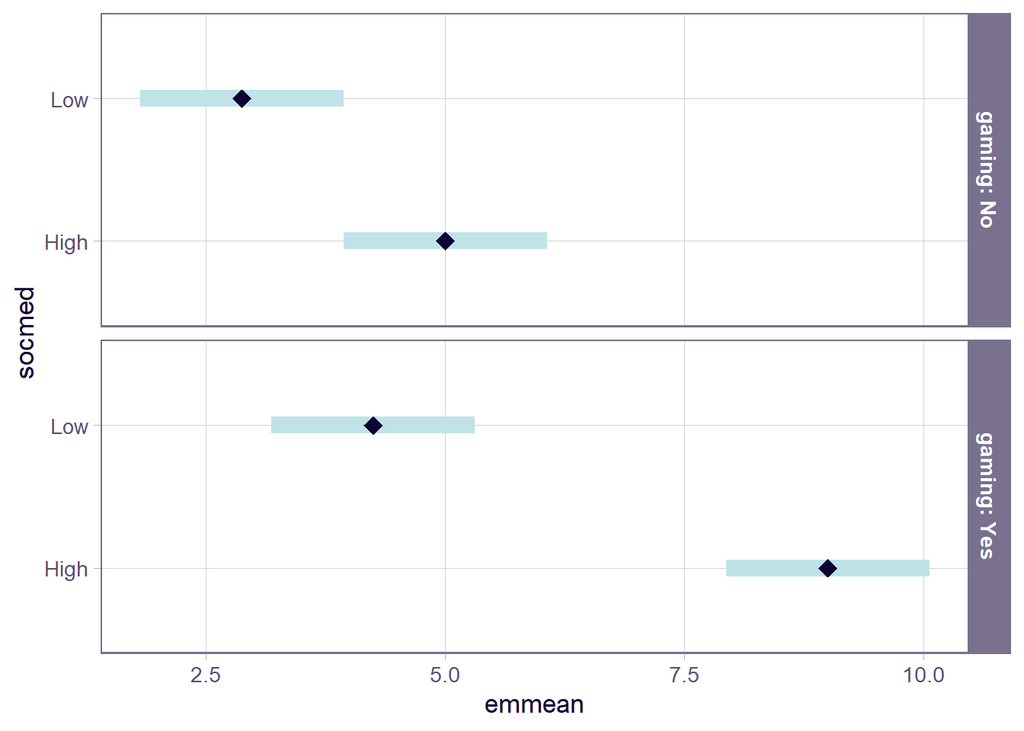

```r
plot(em_mod_lm)
```

5. Comment on how the estimated group means support your result in (a). [2pts.]

The difference between the group means of `socmed` is higher in the `Yes` gaming group compared to the `No` gaming group, which supports the alternative hypothesis that there is an interaction between these two factors.